# Part II - (Features That Affect Bike Ride Duration)

## by (Osayuwamen Aigbogun)

## Investigation Overview

> In this investigation, I was looking at the information about individual rides made in a bike-sharing system covering the greater San Francisco Bay area for the month of February 2019. The main focus was on the features that determine the trip duration.

## Dataset Overview

> This dataset which is the Ford GoBike System Data, includes information about individual rides made in a bike-sharing system covering the greater San Francisco Bay area for the month of February 2019. There were 183412 entries and 16 columns in the dataset, but after cleaning there was 174952 entries and 20 columns. Most features are numeric in nature, with three categorical features which are the member gender, weekday and user type.

## (Distribution of The Trip Duration)

> The trip duration in the dataset take on a vary large range of values, and most are from about 61 seconds to about 10,000 secounds. Plotted on a logarithmic scale, the distribution of duration takes a unimodal shape and is slightly skewed right. The duration started at 200 with trips around 3000,with the peak between 500 and 700, then it falls gradually.

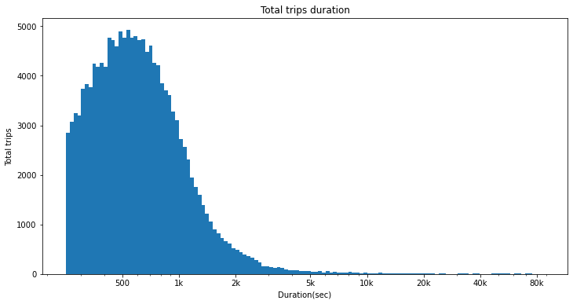

## (Duration by Member Gender)

> We can see that the gender Other have the highest duration, with the Females coming after, while the least are males, that means the Other gender spend most time on trips, while the males spends less time.

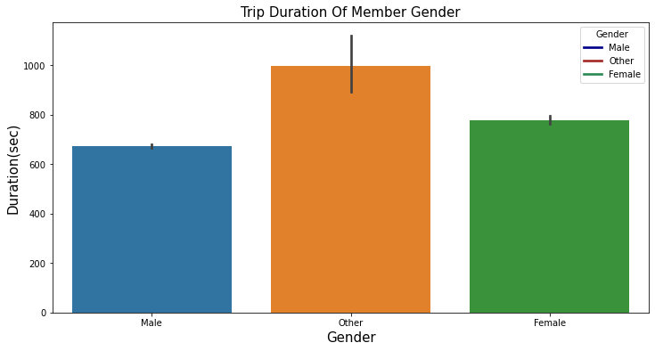

[figure not shown]

## (Duration by Age and User type)

> We can see that most users are subscribers, and the lower part of Age is more then indicating that the younger bikers tend to stay on rides long than the older bikers.

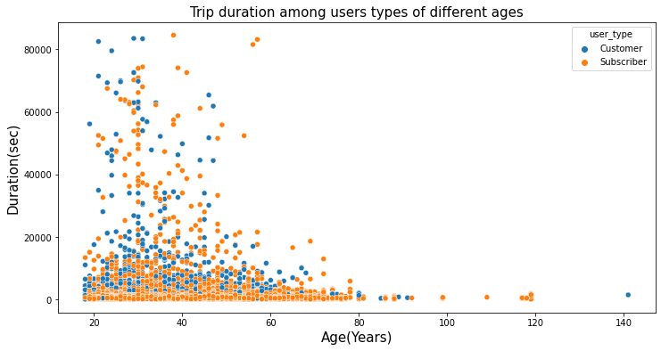